# Visualize integration (level 2): FDC

Paula Soler-Vila & Ramon Massoni-Badosa

2 junio 2021

# 1 Introduction

The objectives of this notebook are:

- Visualize how well we could remove technical variability associated with the assay (scATAC or multiome). We should see a high degree of intermixing between the 2 assays.
- Plot several markers of potential doublets or problematic cells: - scRNAseq doublets determined by 10X Multiome - Scrublet doublet predictions - nCount and nFeatures of scATAC - Chromatin Signature - Projection of the scRNA-seq clusters defined at level 3

The broader objective of level 2 is to eliminate most remaining doublets and poor-quality cells, as we will discuss in future notebooks. These visualizations will allow us to explore this. We will also plot their location in the UMAP obtained at level 1.

# 2 Pre-processing

## 2.1 Load packages

```r
library(Seurat)
library(tidyverse)
library(reshape2)
library(ggpubr)
```

## 2.2 Parameters

```r
# Paths
path_to_obj <- str_c(
  here::here("scATAC-seq/results/R_objects/level_2/"),
  params$cell_type,
  "/",
  params$cell_type,
  "_integrated_level_2.rds",
  sep = ""
)

path_to_obj_RNA <- str_c(
  here::here("scRNA-seq/3-clustering/3-level_3/"),
  params$cell_type,
  "_clustered_level_3_with_pre_freeze.rds",
  sep = ""
)

path_to_doublets <- here::here("scRNA-seq/3-clustering/2-level_2/tmp/doublets_multiome_df_all.rds")

# Functions
source(here::here("scRNA-seq/bin/utils.R"))
```

## 2.3 Load data

```r
# Seurat object
seurat <- readRDS(path_to_obj)
seurat
```

```
## An object of class Seurat
## 270784 features across 113 samples within 1 assay
## Active assay: peaks_macs (270784 features, 36248 variable features)
##  3 dimensional reductions calculated: umap, lsi, harmony
```

```r
seurat_RNA <- readRDS(path_to_obj_RNA)
seurat_RNA
```

```
## An object of class Seurat
## 37378 features across 1508 samples within 1 assay
## Active assay: RNA (37378 features, 3000 variable features)
##  3 dimensional reductions calculated: pca, umap, harmony
```

```r
tonsil_RNA_annotation <- seurat_RNA@meta.data %>%
  rownames_to_column(var = "cell_barcode") %>%
  dplyr::filter(assay == "multiome") %>%
  dplyr::select("cell_barcode", "seurat_clusters")
```

### 2.3.1 Visualization of the data

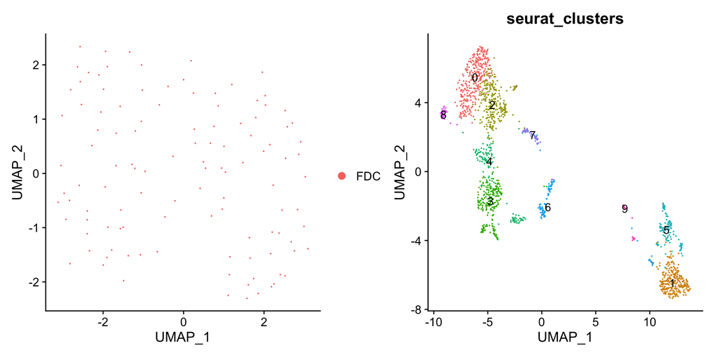

```r
p1 <- DimPlot(seurat,
  pt.size = 0.1)

p2 <- DimPlot(seurat_RNA,
  group.by = "seurat_clusters",
  pt.size = 0.1, label = T) + NoLegend()

p1 + p2
```

# 3 Assess integration

## 3.1 Technical variability |

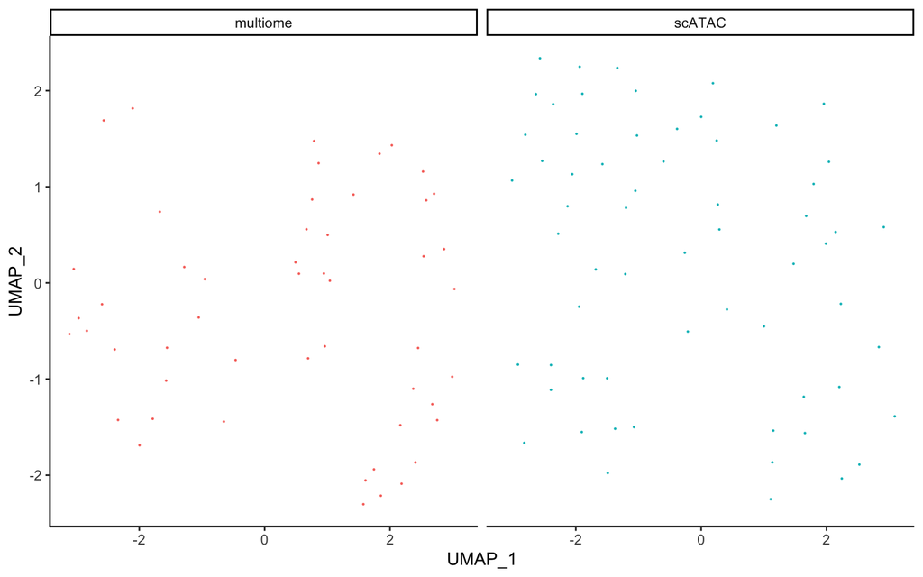

```r
p_assay <- plot_split_umap(seurat, var = "assay")
p_assay
```

## 3.2 Technical variability ||

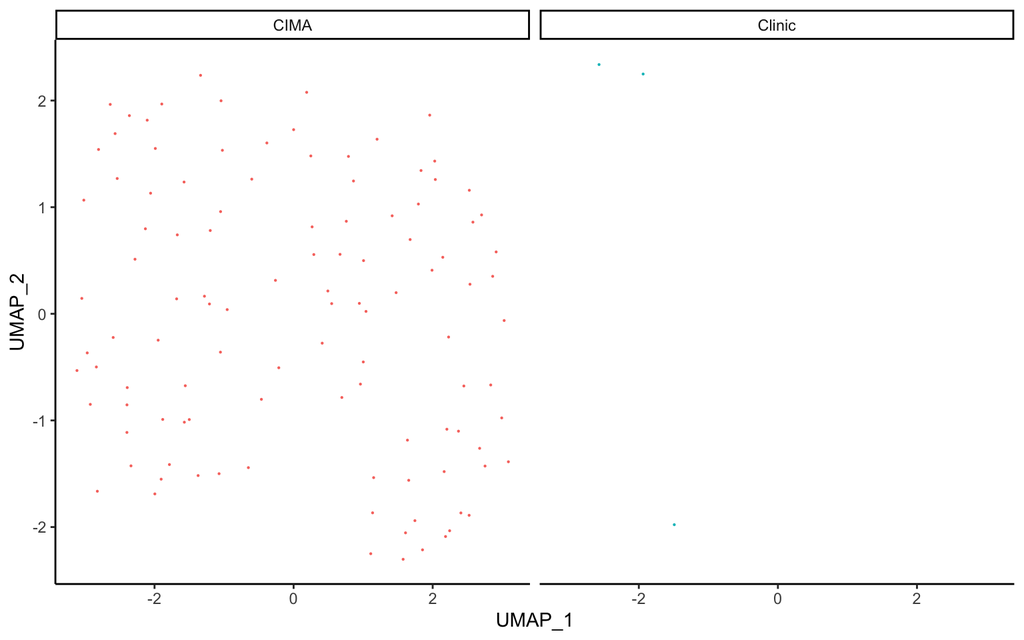

```r
p_assay <- plot_split_umap(seurat, var = "hospital")
p_assay
```

## 3.3 Biological variability |

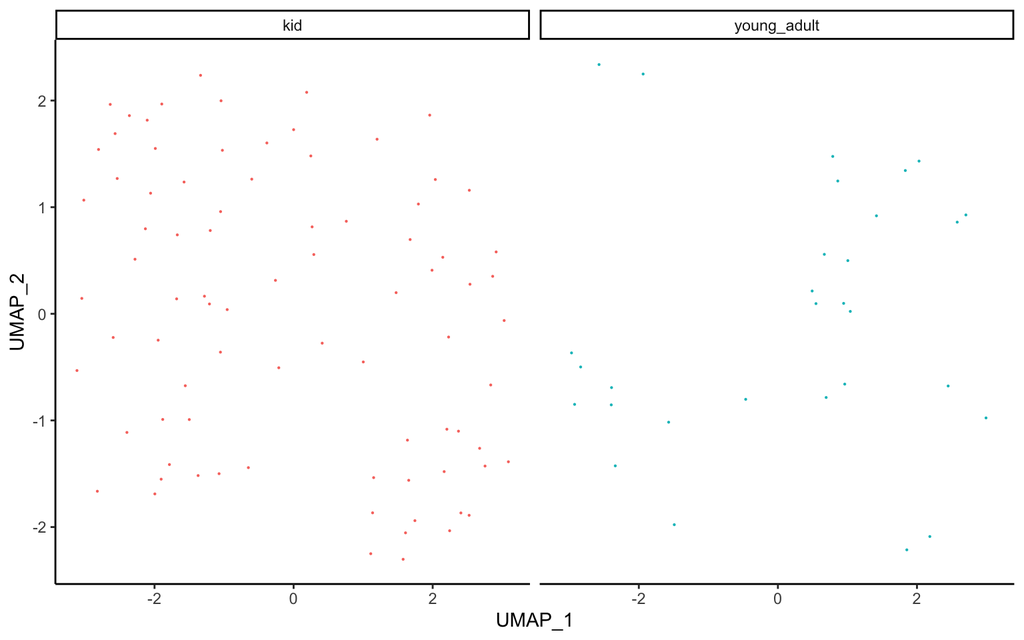

```r
p_assay <- plot_split_umap(seurat, var = "age_group")
p_assay
```

## 3.4 Biological variability ||

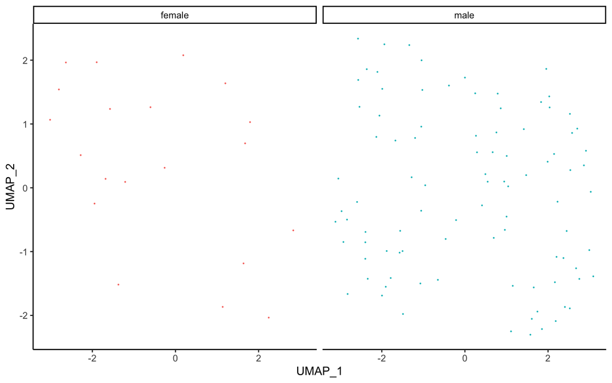

```r
p_assay <- plot_split_umap(seurat, var = "sex")
p_assay
```

# 4 Spot potential doublets

## 4.1 Multiome scRNA-seq data

### 4.1.1 Doublets detected in scRNA-seq data from Multiome.

Here, we can see the count of doublets detected by cell-type. Note that for the level1 annotation there are not doublets detected in the Naive and Memory B cell cluster.

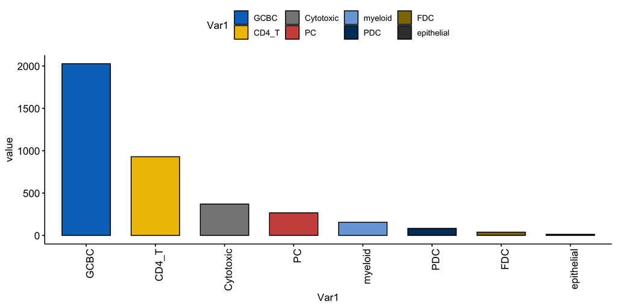

```r
multiome_doublets <- readRDS(path_to_doublets)

dfm = melt(table(multiome_doublets$cell_type))
dfm$value = as.numeric(as.character(dfm$value))
ggbarplot(dfm, x = "Var1", y = "value",
          fill = "Var1",
          palette = "jco",
          sort.val = "desc",
          sort.by.groups = FALSE,
          x.text.angle = 90
          )
```

```r
doublets_cells <- colnames(seurat)[which(colnames(seurat) %in% multiome_doublets$barcode)]
length(doublets_cells)
```

```
## [1] 24
```

## 4.2 Visualize the projection of the doublets cells onto the scATAC-seq UMAP

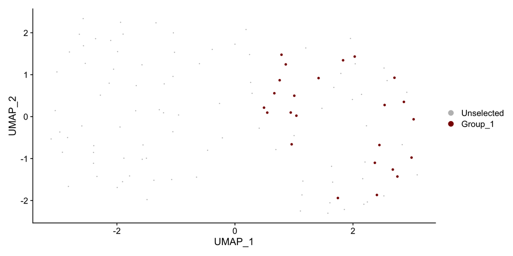

```r
DimPlot(
  seurat, reduction = "umap",
  cols.highlight = "darkred", cols= "grey",
  cells.highlight= doublets_cells,
  pt.size = 0.1
)
```

## Scrublet prediction

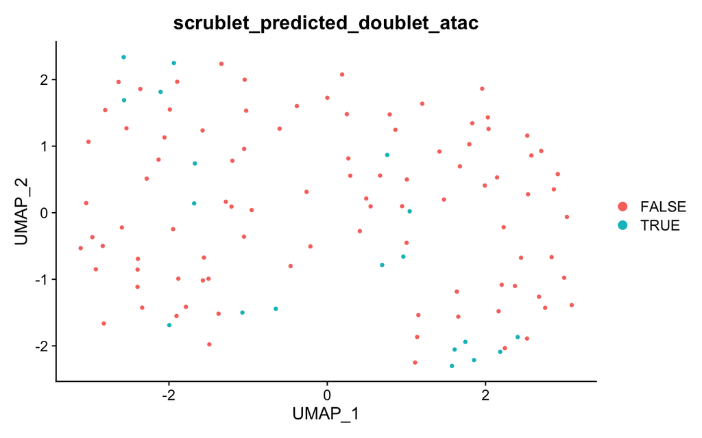

```r
# Scrublet
DimPlot(seurat, group.by = "scrublet_predicted_doublet_atac")
```

```r
table(seurat$scrublet_predicted_doublet_atac)
```

```
##
## FALSE  TRUE
##    94    19
```

## 4.3 QC metrics

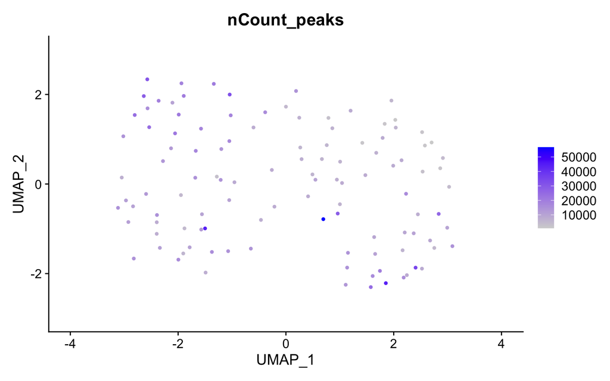

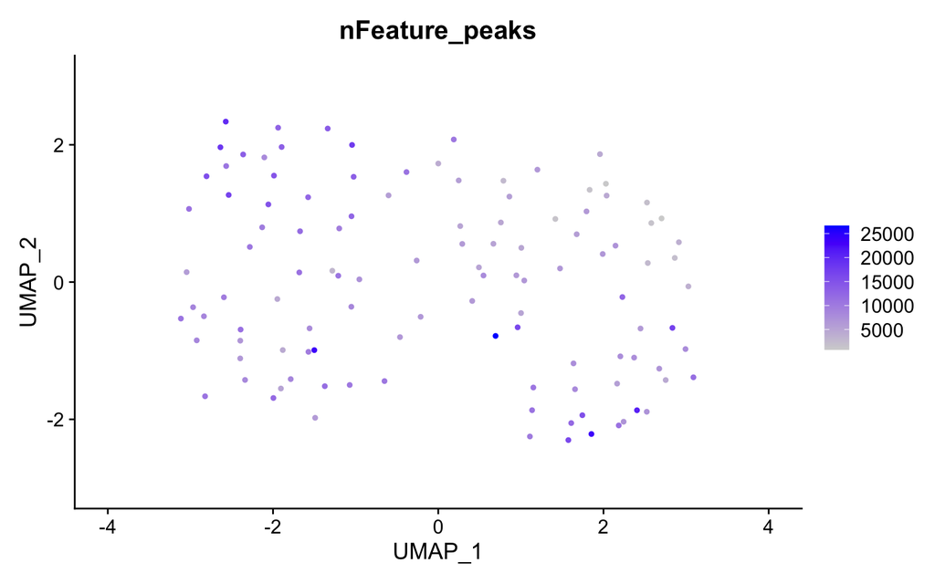

```r
qc_vars <- c(
  "nCount_peaks",
  "nFeature_peaks"
)
qc_gg <- purrr::map(qc_vars, function(x) {
  p <- FeaturePlot(seurat, features = x)
  p
})
qc_gg
```

## 4.4 Annotation probability

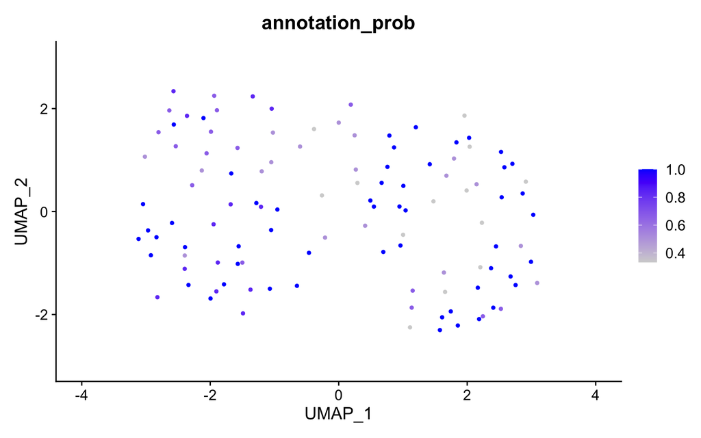

```r
qc_vars <- c(
  "annotation_prob")
qc_gg <- purrr::map(qc_vars, function(x) {
  p <- FeaturePlot(seurat, features = x)
  p
})
qc_gg
```

## 4.5 Chromatin Signature

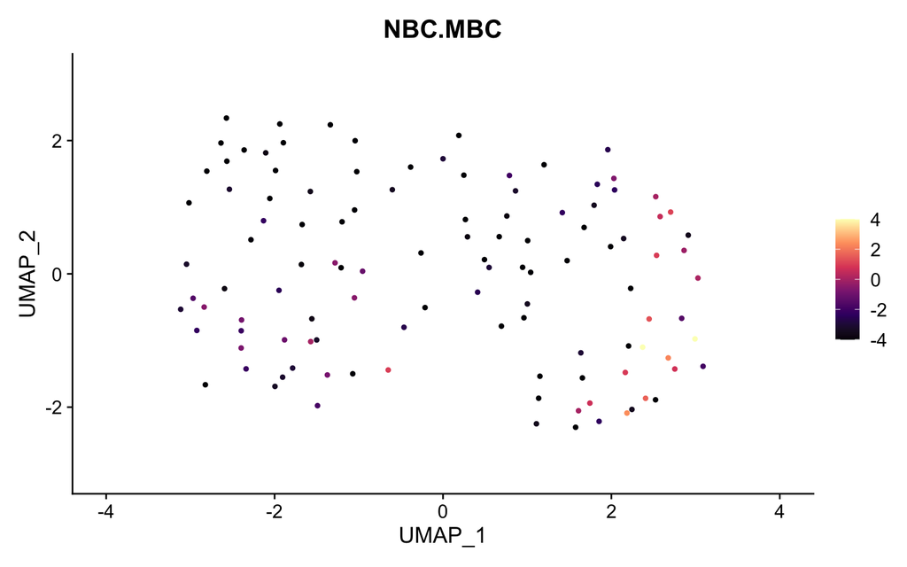

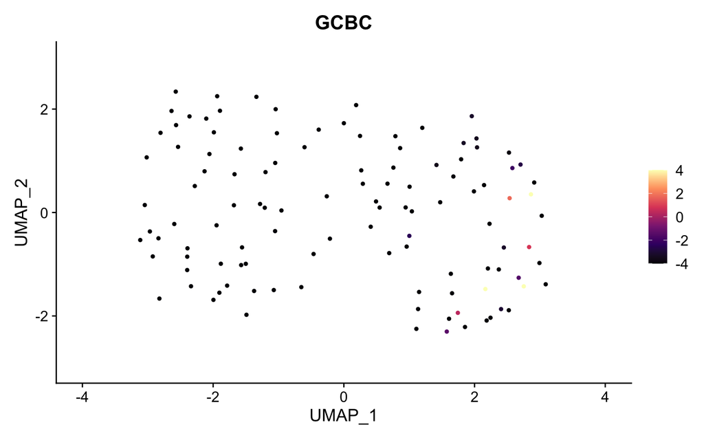

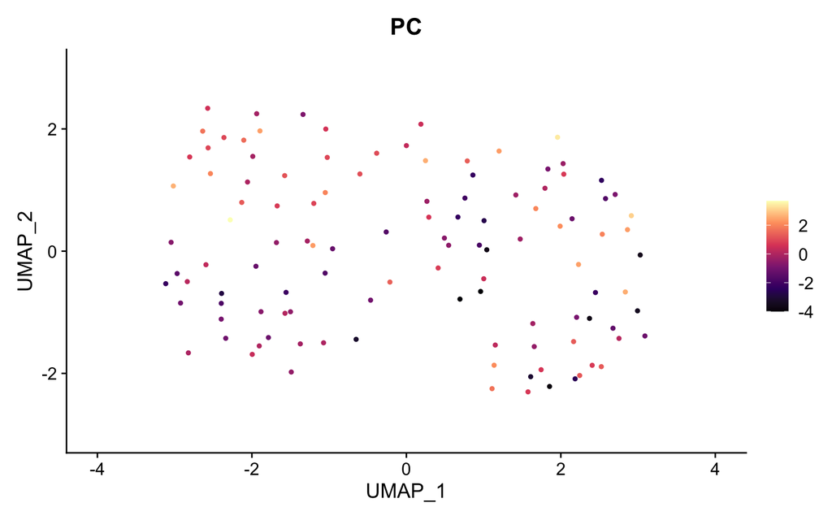

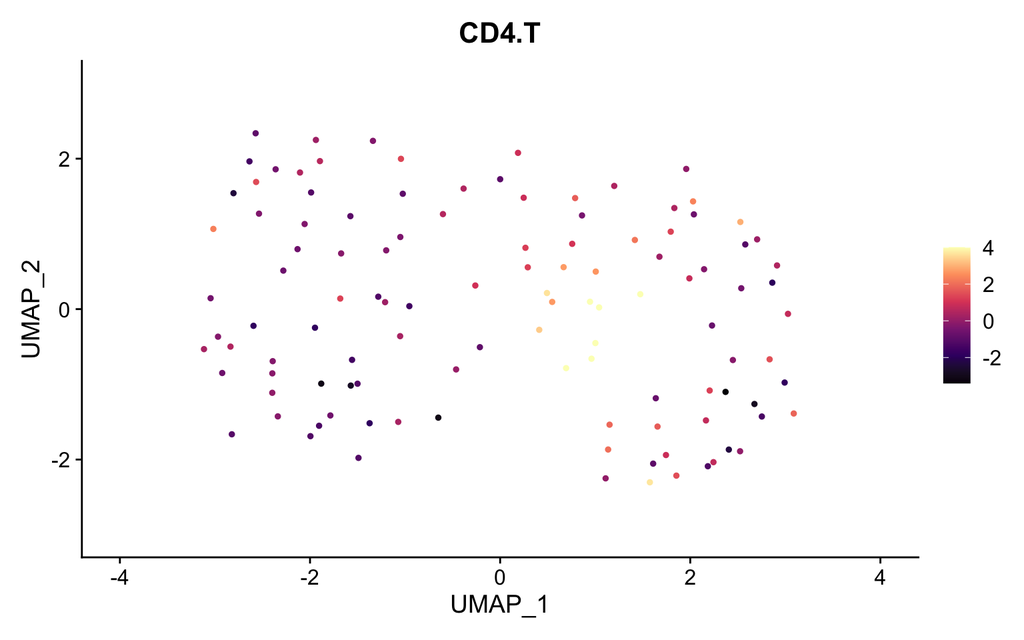

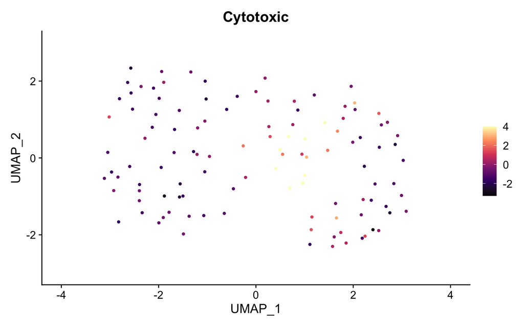

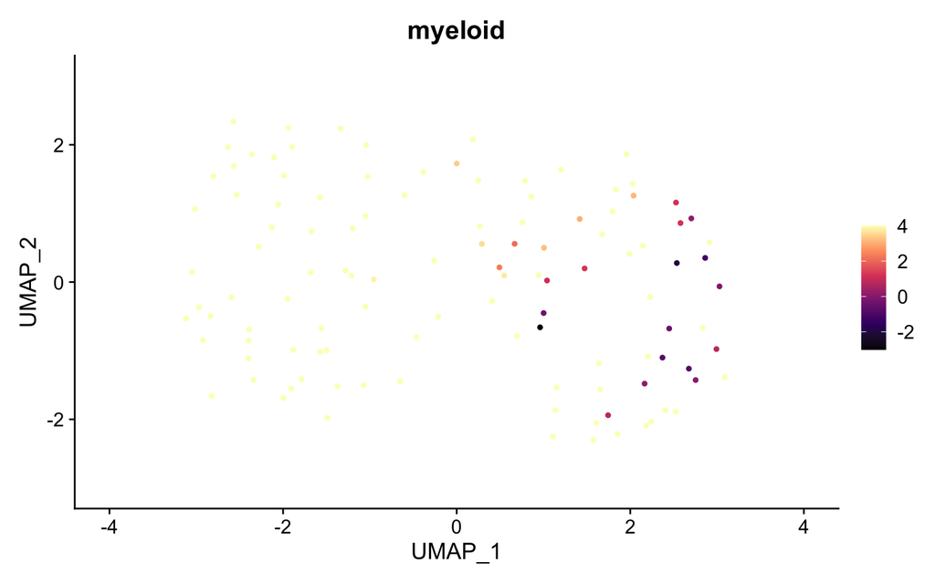

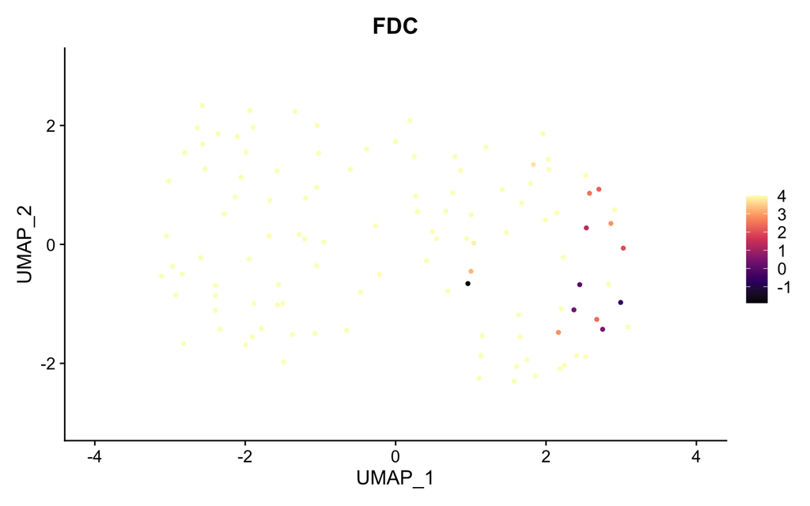

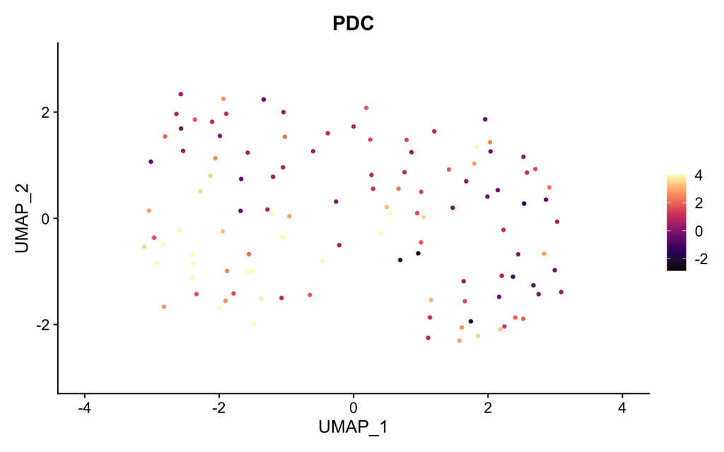

```r
qc_vars <- c("NBC.MBC", "GCBC", "PC", "CD4.T", "Cytotoxic",
             "myeloid", "FDC", "PDC")
qc_gg <- purrr::map(qc_vars, function(x) {
  p <- FeaturePlot(seurat, feature = x, max.cutoff = 4, min.cutoff = -4) + scale_color_viridis_c(option = "magma")
  p
})
qc_gg
```

## 4.6 Projection of the scRNA-seq clusters to scATAC-seq UMAP

Annotation level 3 for scATAC will be defined “a priori” as unannotated and the scRNA annotation will be transfered to the scATAC-multiome cells based on the same cell barcode.

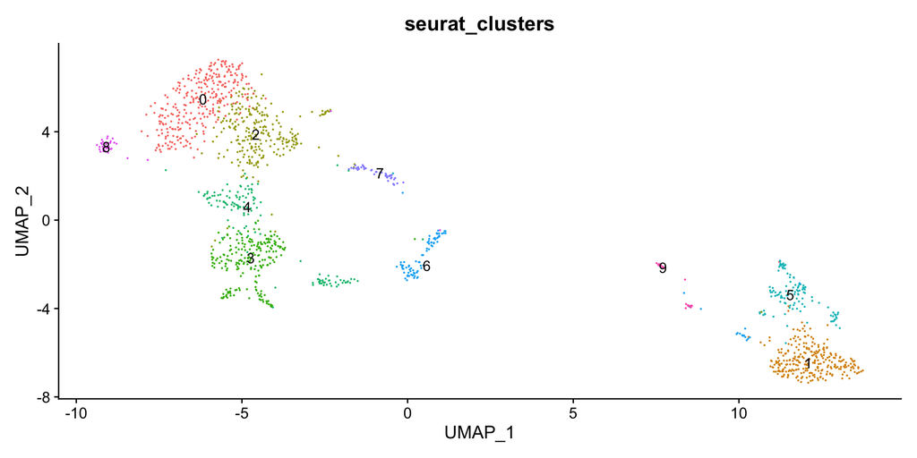

```r
cell_testing <- c("NBC_MBC", "GCBC", "PC", "CD4_T","Cytotoxic")

if (unique(seurat$annotation_level_1) %in% cell_testing){
  seurat_df <- data.frame(cell_barcode = colnames(seurat)[seurat$assay == "scATAC"])
  seurat_df$seurat_clusters <- "unannotated"

  df_all <- rbind(tonsil_RNA_annotation,seurat_df)
  rownames(df_all) <- df_all$cell_barcode
  df_all <- df_all[colnames(seurat), ]

  seurat$seurat_clusters <- df_all$seurat_clusters
  seurat@meta.data$annotation_prob  <- 1
  melt(table(seurat$seurat_clusters))
  table(is.na(seurat$seurat_clusters))

  p3 <- DimPlot(seurat,
              group.by = "seurat_clusters",
              pt.size = 0.5)
  p3
}

p2
```

## 4.7 UMAP level 1

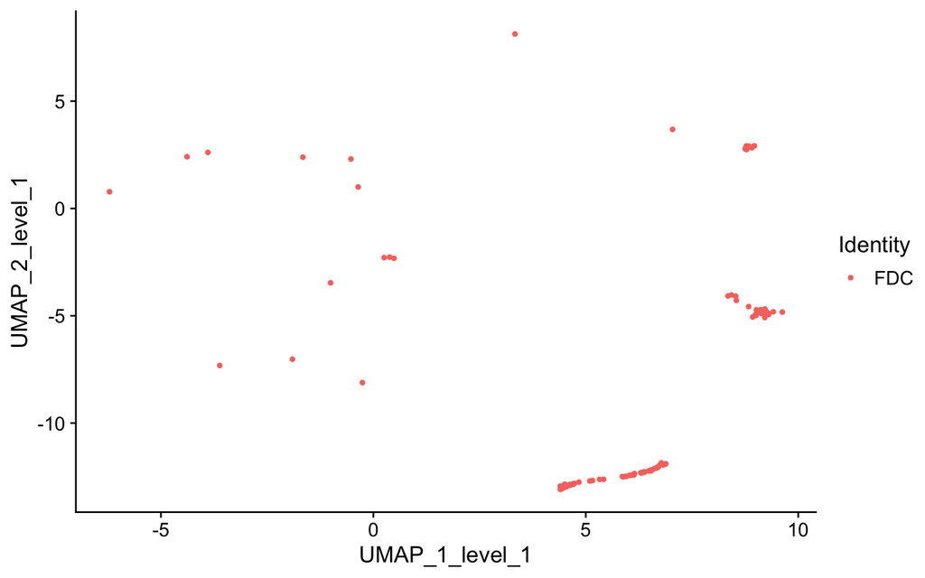

```r
umap_level_1 <- FeatureScatter(
  seurat,
  "UMAP_1_level_1",
  "UMAP_2_level_1",
  group.by = "annotation_level_1"
)
umap_level_1 <- umap_level_1 +
  theme(
    #legend.position = "none",
    plot.title = element_blank()
  )
umap_level_1
```